# Data Science using R

GIACOMO SACCAGGI

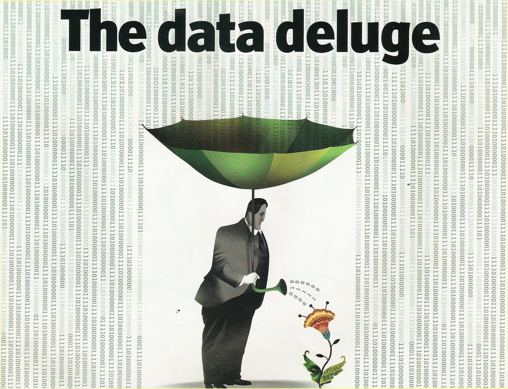

# Introduction

## Machine Learning vs statistics

### Terminology

| Machine Learning |  | Statistics |
| --- | --- | --- |
| target variable | $Y$ | response variable |
| attribute, feature | $x$ | predictor, explanatory variable |
| supervised learning | model $Y$ as a function of $x$ | regression |
| hypothesis | $Y= f(x) + \varepsilon$ | model, regression function |
| instances, examples | $(Y_1,x_1),\ldots,(Y_n,x_n)$ | samples, observations |
| learning | $\displaystyle \hat{f} = \underset{f}{\arg\min} \sum_{i=1}^{n} \mathrm{loss}(Y_i,f(x_i))$ | estimation, fitting |
| classification | $\hat{Y} = \hat{f}(x)$ | prediction |
| generalization error | $\mathbb{E} [\, \mathrm{loss}(Y,\hat{f}(x))\,]$ | risk |

### Focus

| Machine Learning | Statistics |
| --- | --- |
| prediction | significance |

### Culture

| Machine Learning | Statistics |
| --- | --- |
| algorithmic/optimization | modeling |

### Methods

| Machine Learning | Statistics |
| --- | --- |
| decision trees | linear/logistic regression |
| k-nearest-neighbors | discriminant analysis |
| neural networks | mixed models |
| support vector machines | ridge/lasso regression |
| adaboost | GAM |
| random forests | random forests |

## Bias-variance trade-off

### Overfitting’s problem

- Yesterday we observed $n$ pairs of data, the **training set**
  $$(x_1,y_1), (x_2,y_2), \ldots, (x_n,y_n)$$
- Tomorrow we will observe $n = 30$ pairs of data, the **test set**
  $$(x_1,y^*_1), (x_2,y^*_2), \ldots, (x_n,y^*_n)$$
- We consider a **Fixed-X setting**:
  - the training predictor values $x_1,\ldots,x_n$ are treated as fixed (i.e. non-random)
  - the test predictor values $x_1,\ldots,x_n$ exactly match the the training predictor values $x_1,\ldots,x_n$
- The responses in training data were generated artificially by
  $$Y_i = f(x_i)+ \varepsilon_i, \quad i=1,\ldots,n$$
  and the responses in test data by
  $$Y^*_{i}=f(x_i)+\varepsilon^*_i, \quad i=1,\ldots,n$$
  where $\varepsilon_1,\ldots,\varepsilon_n$ and $\varepsilon^*_1,\ldots,\varepsilon^*_n$ are i.i.d. $N(0,\sigma^2)$ with $\sigma=0.01$ and $f$ is a function which we leave unspecified

In the fixed-X setting, the **prediction error** $\mathrm{ErrF}$ is defined by
$$\mathrm{ErrF} = \mathbb{E}(\mathrm{MSE}_{\mathrm{Te}})=\mathbb{E}\left[\frac{1}{n}\sum_{i=1}^{n}( Y^*_i - \hat{f}(x_i))^2\right]= \frac{1}{n}\sum_{i=1}^{n}\mathbb{E}\left[( Y^*_i - \hat{f}(x_i))^2\right]$$

This is the error that we wish to minimize.

### Irreducible and reducible error

- Suppose we want to predict $y^*_i$ by $\hat{y}_i^* = \hat{f}(x_i)$ where $\hat{f}$ is an estimate of $f$ based on the training data.
- The accuracy of $\hat{y}^*_i$ as a prediction for $y^*_i$ depends on two quantities, which we call the **reducible error** and the **irreducible error**.
- We have
  $$\mathbb{E}[(Y^*_{i} - \hat{Y}^*_i)^2] = \mathbb{E}[(f(x_i) + \varepsilon^*_i - \hat{f}(x_i))^2] = \underbrace{\mathbb{E}[(f(x_i) - \hat{f}(x_i))^2]}_{\mathrm{Reducible}} + \underbrace{\mathbb{V}\mathrm{ar}(\varepsilon^*_i)}_{\mathrm{Irreducible}}$$
  where $\mathbb{V}\mathrm{ar}(\varepsilon^*_i) = \sigma^2$.

#### Reducible error

- The reducible error can be decomposed into (squared) **bias** and **variance** of the estimator $\hat{f}$, respectively:
  $$\mathbb{E}[(f(x_i) - \hat{f}(x_i))^2] = \mathbb{E}[(f(x_i) - \mathbb{E}\hat{f}(x_i) + \mathbb{E}\hat{f}(x_i) - \hat{f}(x_i))^2] =
  \underbrace{ [\mathbb{E}\hat{f}(x_i) - f(x_i) ]^2}_{[\mathrm{Bias}(\hat{f}(x_i))]^2} + \underbrace{\mathbb{V}\mathrm{ar}[\hat{f}(x_i)]}_{\mathrm{Variance}(\hat{f}(x_i))}$$
- Now the decomposition of fixed-X prediction error is simply
  $$\mathrm{ErrF} = \sigma^2 + \underbrace{\frac{1}{n}\sum_{i=1}^{n}(\mathbb{E}\hat{f}(x_i) - f(x_i) )^2}_{\mathrm{Bias}^2} + \underbrace{\frac{1}{n}\sum_{i=1}^{n} \mathbb{V}\mathrm{ar}(\hat{f}(x_i))}_{\mathrm{Variance}} = \sigma^2 + [\mathrm{Bias}(\hat{f})]^2+\mathrm{Variance}(\hat{f})$$
- Bias and variance are conflicting entities, and we cannot minimize both simultaneously. We must therefore choose a **trade-off** between bias and variance.

#### Sources of error

- **Irreducible error**  
  Can we ever predict $Y$ from $X$ with zero error? No. Even the true regression function $f$ cannot do this. Note that, even if it were possible to form a perfect estimate for $f$, so that our estimated response took the form $\hat{y}^*_i = f(x_i)$, our prediction would still have some error in it. This is because $Y_i^* = f(x_i) + \varepsilon_i^*$
- **Estimation bias**  
  What happens if our fitted function $\hat{f}$ belongs to a model class that is far from the true $f$? E.g. we choose to fit a linear model in a setting where the true relationship is far from linear?
- **Estimation variance**  
  What happens if our fitted (random) function $\hat{f}$ is itself quite variable? In other words, over different copies of the training data, we end up constructing substantially different functions $\hat{f}?$

### Trade-off

- Reducible Error = Bias $^2$ + Variance
- Models $\hat{f}$ with low bias tend to have high variance
- Models $\hat{f}$ with low variance tend to have high bias
- We can see that even if our prediction is unbiased, i.e. $\mathbb{E}\hat{f}(x_i)= f(x_i)$, we can still incur a large error if it is highly variable
- On the other hand, $\hat{f}(x_i)=0$ has 0 variance but will be terribly biased
- To predict well, we need to balance the bias and the variance

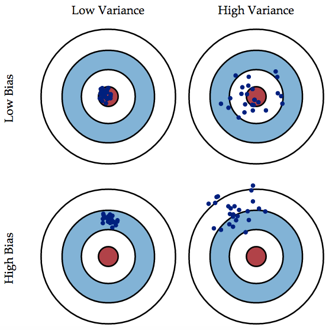

### Cross Validation

### Bootstrap

# Parametric methods

## Best size subset selection

```r
library(MASS)
library(rpart)



set.seed(123)
istrain=sample(c(T,F), nrow(Boston), rep=T)
train=Boston[istrain,]
test=Boston[!istrain,]

library(leaps)


model<-regsubsets(medv ~ ., train, nvmax = ncol(train)-1)

MAT<-model.matrix(medv ~ .,test)
coefi<-list();
for(i in 1:( ncol(train)-1)){
  coefi[[i]]<-list()

  a<-coef(model, id=i)
  b<-names(a)
  c<-MAT[,b]%*%a
  d<-mean((test$medv-c)^2)
  e<-var(c)
  if(i==1){
    risultati<-cbind(d,e)
  }else{
    risultati<-rbind(risultati,cbind(d,e))
  }
  coefi[[i]][[1]]<-a
  coefi[[i]][[2]]<-c
  coefi[[i]][[3]]<-d
  names(coefi[[i]])<-c("coef","test.fitted","MSE")
};risultati<-data.frame(risultati);rownames(risultati)<-names(coefi)<-paste("N. variable ->",1:length(coefi));colnames(risultati)<-c("MSE","VAR");coefi[[ncol(train)]]<-risultati;names(coefi)[ncol(train)]<-"Model"


coefi$Model
```

```
                       MSE      VAR
N. variable -> 1  30.78220 38.04960
N. variable -> 2  24.11510 43.21086
N. variable -> 3  20.93024 52.60300
N. variable -> 4  19.90347 54.04740
N. variable -> 5  20.48882 59.43248
N. variable -> 6  19.85124 59.58166
N. variable -> 7  20.66085 62.64132
N. variable -> 8  20.09779 62.78168
N. variable -> 9  19.82441 64.14192
N. variable -> 10 19.54135 61.33108
N. variable -> 11 19.00319 62.07655
N. variable -> 12 19.00560 62.09425
N. variable -> 13 19.00507 62.09422
```

### Problem

## Polynomial Regression

### Problem

We consider here a very simple example serving as the prototype for much more complex and realistic circumstances. Let us presume that yesterday we observed $n = 30$ pairs of data, the **training set**
$$(x_1,y_1), (x_2,y_2), \ldots, (x_n,y_n)$$
and that tomorrow we will observe $n = 30$ pairs of data, the **test set**
$$(x_1,y^*_1), (x_2,y^*_2), \ldots, (x_n,y^*_n)$$

Here we assume that

- the training predictor values $x_1,\ldots,x_n$ are treated as fixed (i.e. non-random)
- the test predictor values $x_1,\ldots,x_n$ exactly match the the training predictor values $x_1,\ldots,x_n$

This setting is called **Fixed-x setting**.

The responses in training data were generated artificially by
$$Y_i = f(x_i)+ \varepsilon_i, \quad i=1,\ldots,n$$
and the responses in test data by
$$Y^*_{i}=f(x_i)+\varepsilon^*_i, \quad i=1,\ldots,n$$
where

- $\varepsilon_1,\ldots,\varepsilon_n$ and $\varepsilon^*_1,\ldots,\varepsilon^*_n$ are i.i.d. $N(0,\sigma^2)$ with $\sigma=0.01$
- $f$ is a function which we leave unspecified, the only requirement is that this function should follow an essentially regular trend. Clearly, to generate the data, we had to choose a specific function (not a polynomial), but we do not disclose our choice.

Today we wish to obtain an estimate $\hat{f}$ of $f$ based on the training data that allows us to generate predictions for future tororrow data, i.e.
$$\hat{y}^*_i = \hat{f}(x_i), \quad i=1,\ldots,n.$$

```r
# import data from the web
library(readr)
df <- read_table2("http://azzalini.stat.unipd.it/Book-DM/yesterday.dat")[-31,]
# create training set
train <- data.frame(x=df$x, y=df$y.yesterday)
```

The training data are shown in the scatterplot:

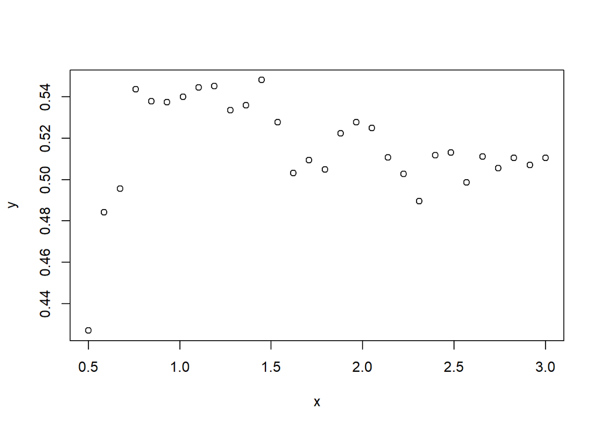

```r
plot( y ~ x , train)
```

```r
lm(y ~ x , train)
```

```
Call:
lm(formula = y ~ x, data = train)

Coefficients:
(Intercept)            x
   0.520627    -0.002906
```

In this problem we can observe that the coefficient is more or less equal to 0 and this model dosen’t capture the $y$’s variation.

### Solution: Polynomial regression

A reasonable choice consists of using polynomial regression (of degree $d$)
$$f(x) = \beta_0 + \beta_1 x + \beta_2 x^2 + \ldots + \beta_d x^{d}$$

If we have no information to guide us in choosing the degree $d$ of the polynomial, we first consider all possible degrees from 0 to $n-1$, thereby introducing $p=d+1$ parameters ranging from $1$ to $n$, in addition to $\sigma$.

Let’s try a 3rd degree polynomial model ($d=3$)

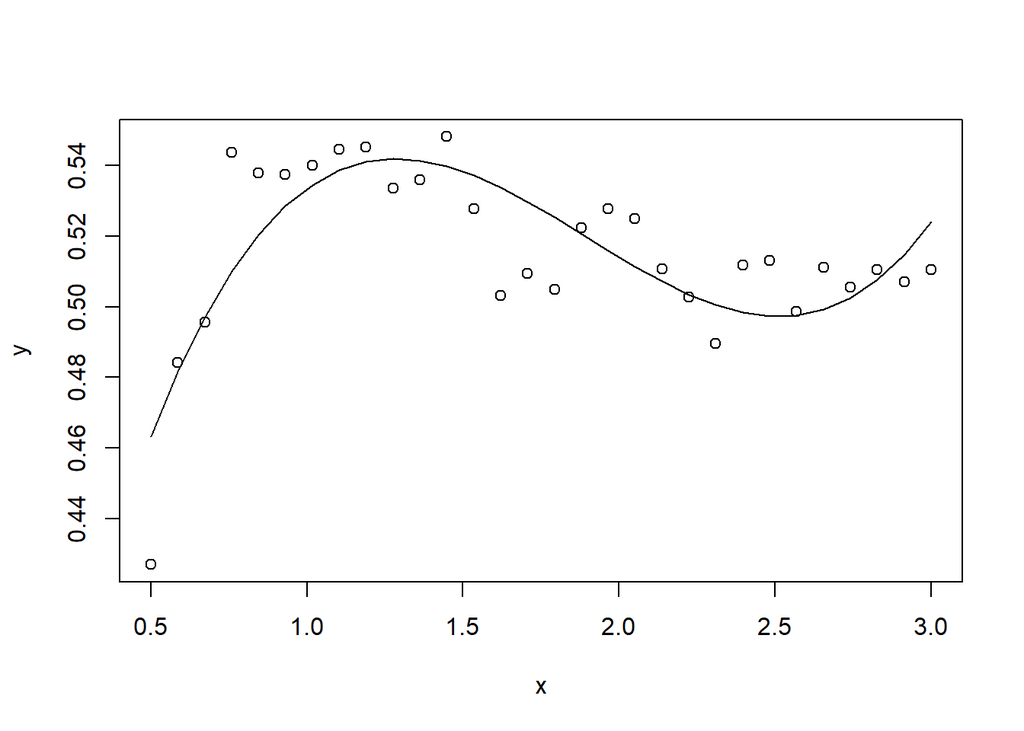

```r
# create test set
test = data.frame(x=train$x, y=df$y.tomorrow)

# 3rd degree polynomial regression fit
fit <- lm( y ~ poly(x, degree=3), train)
yhat <- predict(fit, newdata=test)

# plot
plot( y ~ x , train)
lines( yhat ~ x, train)
```

Is this a good fit? We can compute $\mathrm{MSE}_{\mathrm{Tr}}$ for the 3rd degree polynomial model.

```r
# compute MSE.tr for the 3rd degree polynomial fit
MSE.tr <- mean( (train$y - yhat)^2 )
MSE.tr
```

```
[1] 0.0002085353
```

Now we compute $\mathrm{MSE}_{\mathrm{Tr}}$ for all possible degrees from 0 to $n-1$.

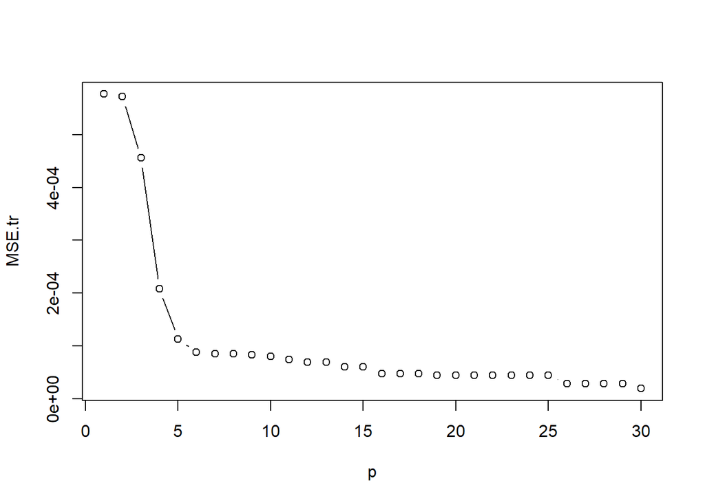

```r
n <- nrow(train)
ds = 0:(n-1)
ps = ds + 1
# function to fit polynomial model of degree d
fun <- function(d) if (d==0) lm(y~1, train) else lm(y~poly(x,degree=d, raw=T), train)
fits <- sapply(ds, fun)

# compute MSE.tr for all degrees
MSEs.tr <- unlist( lapply(fits, deviance) )/n
plot(ps, MSEs.tr, type="b", xlab="p", ylab="MSE.tr")
```

### Overfitting

As already mentioned, we need to use an estimate $\hat{f}$ based on the training data to generate predictions for future, yet-to-be-seen data produced by the same generating mechanism. We now evaluate the quality of the prediction using yesterday’s fit of the polynomials for the new $y^*_i$, as if we could obtain tomorrow’s data today. Let’s try with the 20th degree polynomial:

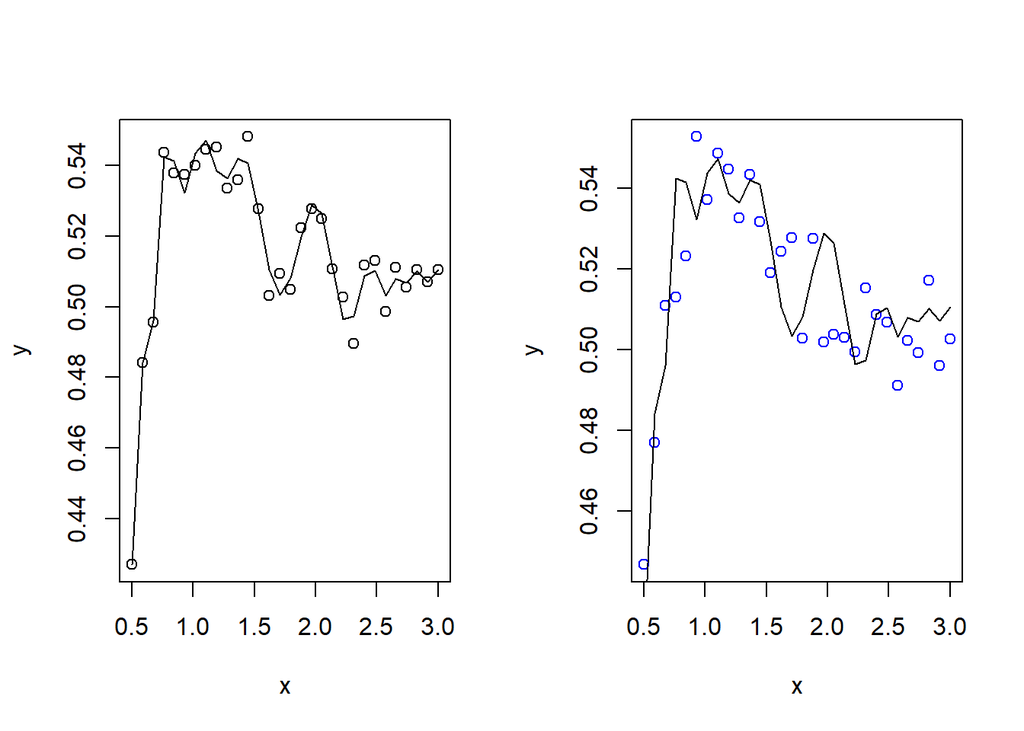

```r
# 20th degree polynomial fit
fit <- lm( y ~ poly(x, degree=20), train)
yhat <- predict(fit, newdata=test)
# plots
op <- par(mfrow = c(1, 2))
plot( y ~ x , train)
lines(yhat ~ x, train)
plot( y ~ x , test, col=4)
lines(yhat ~ x, train)
```

```r
par(op)
```

The figure shows yesterday and tomorrow’s data with the predictions from the 20th degree polynomial. It is noteworthy that this high-degree polynomial fits very well the old points but fluctuate and no longer fit the new points. Here the model **overfits** the training data.

Now we compute $\mathrm{MSE}_{\mathrm{Te}}$ for all possible degrees from 0 to $n-1$.

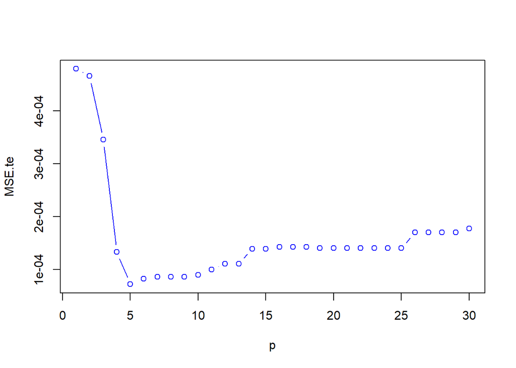

```r
# compute predictions for all degrees
yhats <- lapply(fits, predict)
# compute MSE.te for all degrees
MSEs.te <- unlist(lapply(yhats,
           function(yhat) mean((test$y - yhat)^2)
           ))
# plot
plot(ps, MSEs.te, type="b", col=4, xlab="p", ylab="MSE.te")
```

```r
# which p gives minimum MSE.te?
ps[which.min(MSEs.te)]
```

```
[1] 5
```

Here the $\mathrm{MSE}_{\mathrm{Te}}$ decreases to a certain point and then increases.

# Nonparametric methods

## Intro

Up to now, we have only dealt with parametric methods, but it is also worth exploring **nonparametric** ones. Non-parametric methods do not make explicit assumptions about the functional form of $f$ (e.g. polynomials). This means to leave data `speak for themselves’ in a free way.

- Such approaches can have a major advantage over parametric approaches: by avoiding the assumption of a particular functional form for $f$, they have the potential to accurately fit a wider range of possible shapes for $f$.
- But non-parametric approaches do suffer from a major disadvantage: since they do not reduce the problem of estimating $f$ to a small number of parameters, a very large number of observations is required in order to obtain an accurate estimate for $f$.

In general, as the flexibility of a method increases, its interpretability decreases.

- [Fig. 2.7 ISLR](http://www-bcf.usc.edu/~gareth/ISL/Chapter2/2.7.pdf)

[interactive chart not shown]

## K-Nearest Neighbors

### Theory

Suppose we want to make a prediction at some $x_0$. Define the neighbourhood $N_k(x_0)$ to be the set of $k$ training observations having values $x_i$ closest to $x_0$ in Euclidean norm $\| x_i - x_0 \|=\sqrt{(x_i - x_0)^\mathsf{T}(x_i - x_0)}$

$$\hat{f}(x_0) = \frac{1}{k}\sum_{i \in N_k(x_0)} y_i$$

As in the case of regression, the number $k$ is a **tuning parameter** related to the complexity of the model. By varying the number of neighbours $k$, we can achieve a wide range of flexibility in the estimated function.

- Small $k$ corresponds to a more flexible fit: the $k$ points are closer to target $x_0$ (low bias), but averages based on a small sample have high variance.
- Large k corresponds to a less flexible fit: it includes points far from $x_0$ (high bias), but have smaller variance.
- Ordinarily, since we are computing a distance, we would want to **center** and **scale** the predictors.

The best value for $k$ depends on how smooth the true function $f$ is, and how noisy $y$ is. We can try different values of $k$ and use e.g. cross-validation to select one value.

Note that kNN is a special case of **local regression** of degree 0, when a nonconstant bandwidth along the x-axis is chosen.

### Exercize

Do the following exercize. Consider the $n=250$ points version of the yesterday-tomorrow data:

- the true $f$, named `f.true250`, is given [here](http://azzalini.stat.unipd.it/Book-DM/f_true.R)
- the true $\sigma$ is $0.01$
- the $x$ values are given by `x = seq(0.5,3,length=250)`
1. Obtain the training set and test set by

```r
set.seed(123)
y = ftrue + rnorm(n, 0,sigmatrue)
ystar = ftrue + rnorm(n, 0,sigmatrue)
train = data.frame(x=x, y=y)
test = data.frame(x=x, y=ystar)
```

2. Install the R package `kknn` and perform kNN with $k=21$ by using the function `kknn(y ~ x, train, test, kernel = "rectangular", k = 21)`

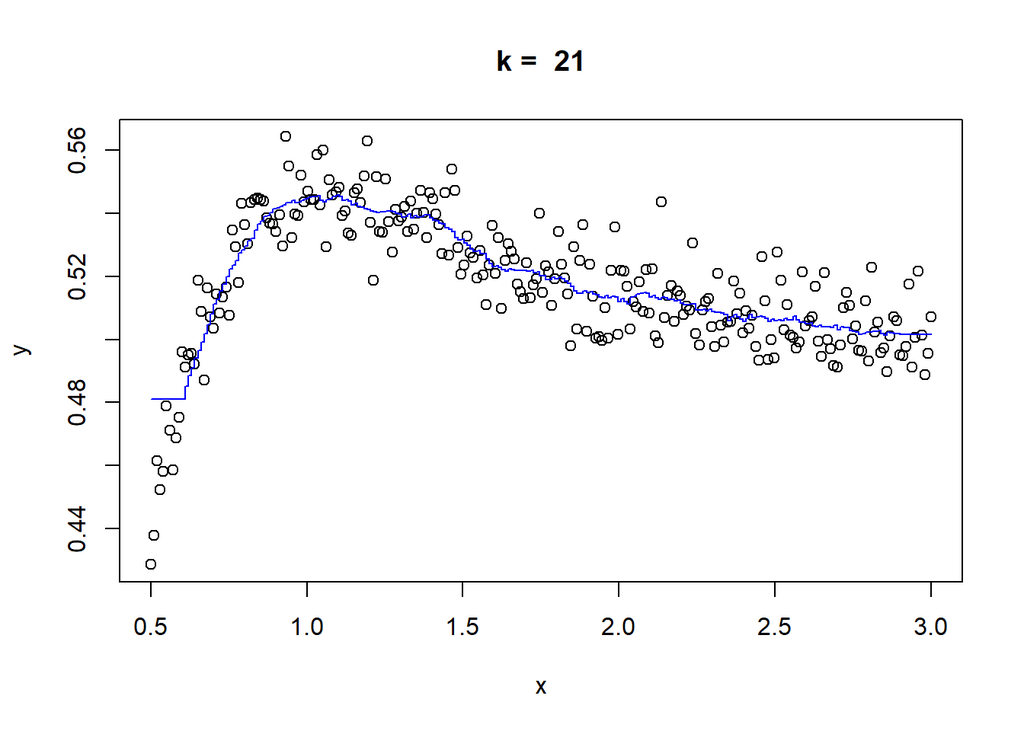

3. Compute MSE.tr and MSE.te for $k=21$

```
[1] "kNN with k = 21 MSE.tr = 0.000111634315005528"
```

```
[1] "kNN with k = 21 MSE.te = 0.000133371260197987"
```

4. Select the tuning parameter $k$ via leave-one-out by the function `train.kknn(y ~ x, train, ks = 1:40, kernel = "rectangular")`

```
[1] "Best k with LOOCV = 7"
```

5. Compute MSE.tr and MSE.te for $k=1,2,\ldots,40$ and find the $k$ corresponding to the minimum MSE.te

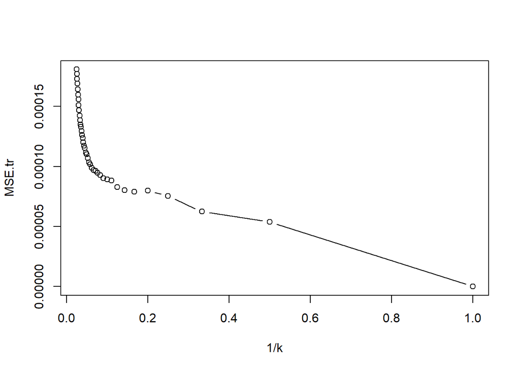

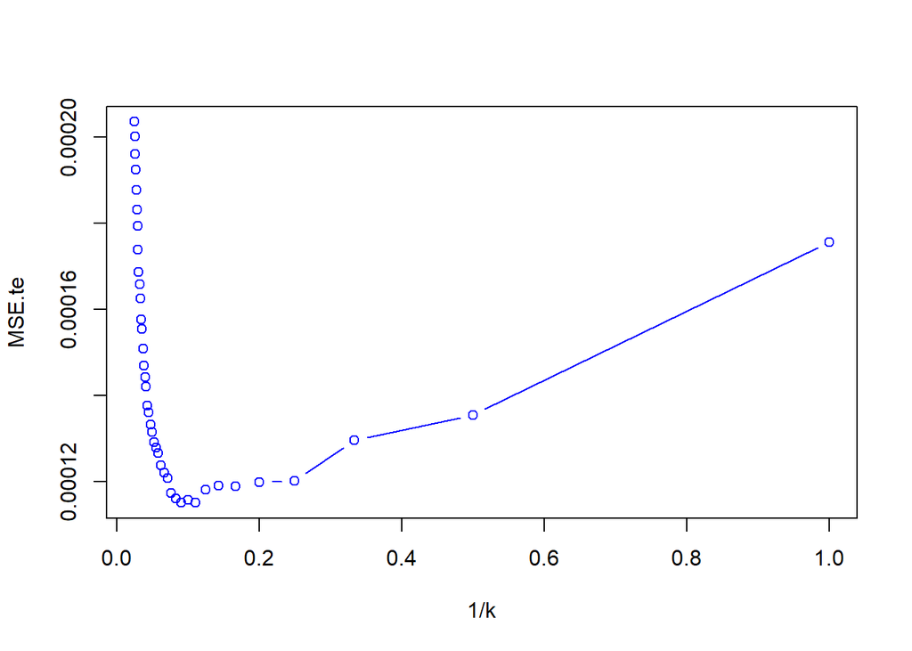

```
[1] 9
```

6. For the fixed-x setting, theoretical results show that for kNN
   $$\mathrm{OptF} = \mathbb{E}(\mathrm{MSE}_{\mathrm{Te}}) - \mathbb{E}(\mathrm{MSE}_{\mathrm{Tr}}) = \frac{2}{n}\sum_{i=1}^{n}\mathbb{C}\mathrm{ov}(y_i,\hat{f}(x_i))= \frac{2\sigma^2}{k}$$
   Find the $k$ corresponding to the minimum
   $$\widehat{\mathrm{Err}} = \mathrm{MSE}_{\mathrm{Tr}} + \frac{2\sigma^2}{k}$$

```
[1] 8
```

7. In the fixed-x setting, theoretical results show that for kNN
   $$\mathrm{Variance}(\hat{f})=\frac{1}{n}\sum_{i=1}^{n}\mathbb{V}\mathrm{ar}[\hat{f}(x_i)] = \frac{\sigma^2}{k}$$
   Remember that the expected value $\mathbb{E}\hat{f}(x_i)$ can be obtained by fitting the kNN model using $y_i = f(x_i)$. This allows to compute the squared bias $[\mathrm{Bias}(\hat{f})]^2= \frac{1}{n}\sum_{i=1}^{n}(\mathbb{E}\hat{f}(x_i) - f(x_i) )^2$. Compute the redubile error $[\mathrm{Bias}(\hat{f})]^2 + \mathrm{Variance}(\hat{f})$ for $k=1,2,\ldots,40$ and find the $k$ that minimize it.

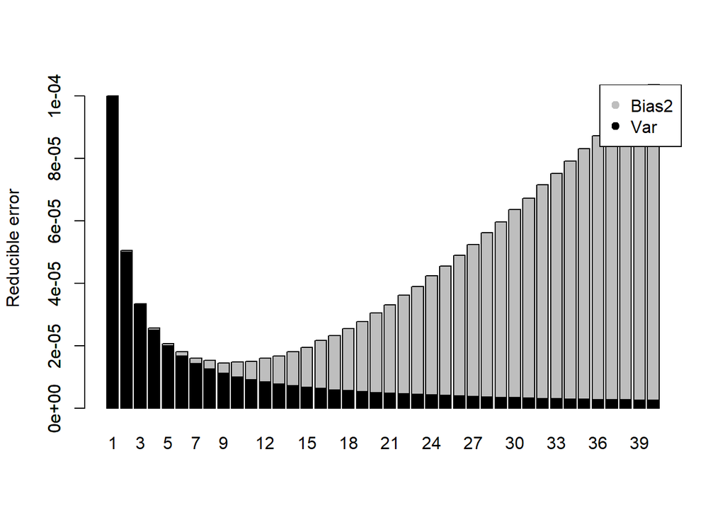

```
[1] 9
```

### The caret package

The [caret](http://topepo.github.io/caret/index.html) package (short for _C_lassification _A_nd _RE_gression _T_raining) is a set of functions that attempt to streamline the process for creating predictive models. The package contains tools for:

- data splitting
- pre-processing
- feature selection
- model tuning using resampling
- variable importance estimation

as well as other functionality.

The package utilizes a number of R packages but tries not to load them all at package start-up. The package “suggests” field includes 76 packages. `caret` loads packages as needed and assumes that they are installed. Install caret using

```r
 install.packages("caret", dependencies = c("Depends", "Suggests"))
```

to ensure that **all** the needed packages are installed.

- The main help pages for the package are at https://topepo.github.io/caret/
- The book [Applied Predictive Modeling](http://appliedpredictivemodeling.com/) can be view as an introduction to the `caret` package.

One of the primary tools in the package is the `train` function which can be used to evaluate, using resampling, the effect of model tuning parameters on performance choose the optimal model across these parameters estimate model performance from a training set. More formally, the **pseudocode** is

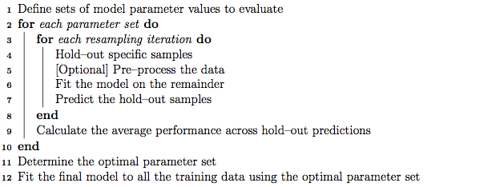

The most basic syntax to do this is:

```r
library(caret)
fit.knn = train(
  y ~ ., train,
  method = "knn")
# result
fit.knn
```

```
k-Nearest Neighbors

250 samples
  1 predictor

No pre-processing
Resampling: Bootstrapped (25 reps)
Summary of sample sizes: 250, 250, 250, 250, 250, 250, ...
Resampling results across tuning parameters:

  k  RMSE        Rsquared   MAE
  5  0.01146809  0.7261602  0.008978840
  7  0.01105863  0.7438812  0.008674320
  9  0.01095533  0.7485859  0.008545349

RMSE was used to select the optimal model using the smallest value.
The final value used for the model was k = 9.
```

- To modify the resampling method, a `trainControl` function is used. The option method controls the type of resampling and defaults to `boot`. Another method, `repeatedcv`, is used to specify repeated $K$-fold cross-validation (and the argument repeats controls the number of repetitions). $K$ is controlled by the number argument and defaults to 10.
- To change the candidate values of the tuning parameter, either of the `tuneLength` or `tuneGrid` arguments can be used. The train function can generate a candidate set of parameter values and the tuneLength argument controls how many are evaluated. The `tuneGrid` argument is used when specific values are desired.

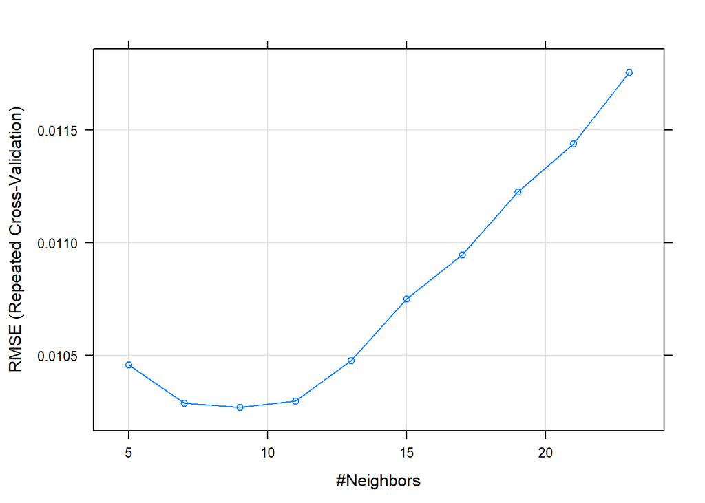

```r
rcv <- trainControl(
  method = "repeatedcv",
  number = 5,
  repeats = 2
)
fit.knn = train(
  y ~ ., train,
  method = "knn",
  trControl=rcv,
  tuneLength = 10)
plot(fit.knn)
```

```r
fit.knn$bestTune
```

```
  k
3 9
```

Compare to polynomial regression of degree $d=6$ (which is the best choice for this example)

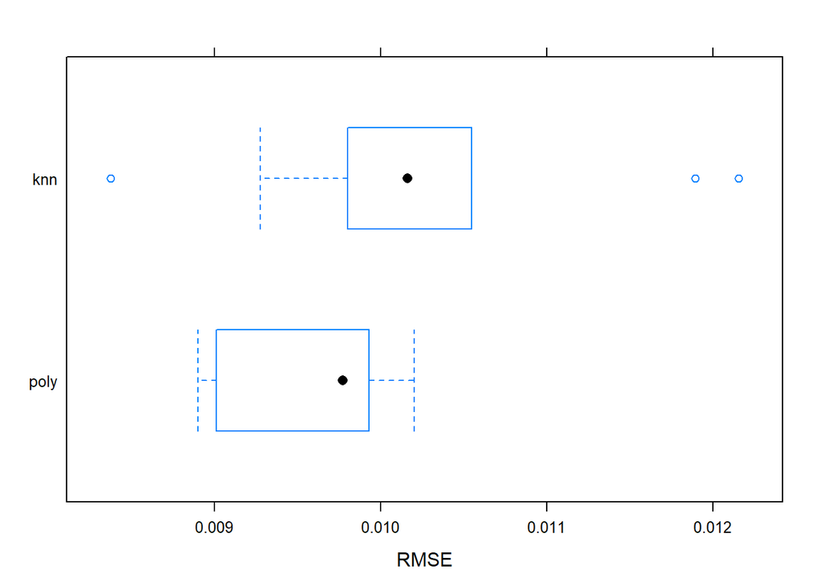

```r
fit.poly = train(
  y ~ poly(x,degree=6), train,
  method = "lm",
  trControl=rcv)
models = list(
    knn=fit.knn,
    poly=fit.poly
  )
resamps = resamples(models)
bwplot(resamps, metric = "RMSE")
```

```r
yhats = predict(models, newdata=test)
lapply(yhats, function(yhat) sqrt( mean( (yhat - test$y)^2) ) )
```

```
$knn
[1] 0.01073157

$poly
[1] 0.01008743
```

# Shrinkage Methods

## Intro

Ridge regression and Lasso

#### Problems in linear regression

1. Collinearity
2. Overfitting: when $p \approx n$, the linear regression fit often has low bias but high variance
3. High-dimensional data: when $p>n$, we have super-collinearity

#### Regularization

- How we deal with problems 1, 2 and 3? The short answer is **regularization**
- Least squares:

$$\min_{\boldsymbol{\beta} \in \mathbb{R}^p} \| \mathbf{y} - \mathbf{x}\boldsymbol{\beta} \|^2_2$$

- **Penalized form**

$$\min_{\boldsymbol{\beta} \in \mathbb{R}^p} \| \mathbf{y} - \mathbf{x}\boldsymbol{\beta} \|^2_2+ P(\boldsymbol{\beta})$$
where $P(\cdot)$ is some (typically convex) penalty function

- **Constrained form**

$$\min_{\boldsymbol{\beta} \in \mathbb{R}^p} \| \mathbf{y} - \mathbf{x}\boldsymbol{\beta} \|^2_2 \quad \mathrm{subject\,\,to\,\,} \boldsymbol{\beta}\in C$$

where $C$ is some (typically convex) set

- At its core, regularization provides us a way of navigating the bias-variance trade-off

#### General difference

Ridge or lasso are forms of regularized linear regressions. The regularization can also be interpreted as prior in a maximum a posteriori estimation method. Under this interpretation, the ridge and the lasso make different assumptions on the class of linear transformation they infer to relate input and output data. In the ridge, the coefficients of the linear transformation are normal distributed and in the lasso they are Laplace distributed.

In the lasso, this makes it easier for the coefficients to be zero and therefore easier to eliminate some of your input variable as not contributing to the output.

There are also some practical considerations. The ridge is a bit easier to implement and faster to compute, which may matter depending on the type of data you have.

If you have both implemented, use subsets of your data to find the ridge and the lasso and compare how well they work on the left out data. The errors should give you an idea of which to use.

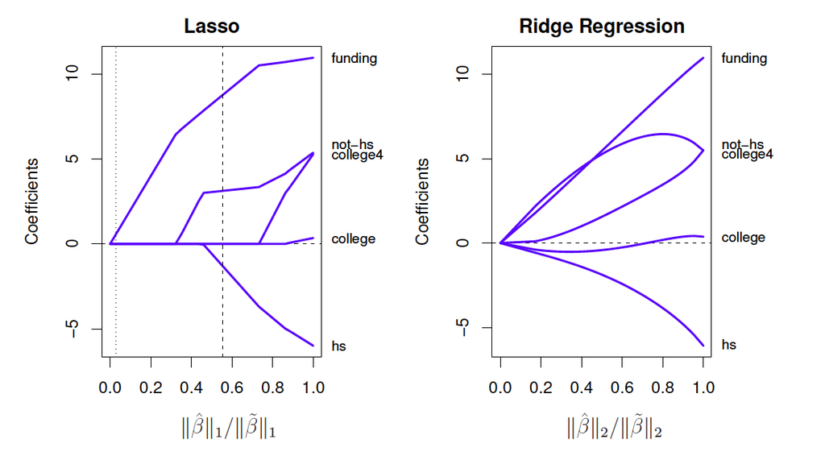

#### Prostate data

For these argument we use Prostate data:

- The response variable `lpsa` is the log prostate specific antigen level of men who had surgery for prostate cancer
- Predictors:
  - `lcavol` : log cancer volume
  - `lweight` : log prostate weight
  - `age` : in years
  - `lbph` : log of the amount of benign prostatic hyperplasia
  - `svi` : seminal vesicle invasion
  - `lcp` : log of capsular penetration
  - `gleason` : a numeric vector
  - `pgg45` : percent of Gleason score 4 or 5
- The data are split into training set and test set with $n=67$ and $m=30$ observations, respectively

```r
require(ElemStatLearn)
train = prostate[prostate$train,-10]
test = prostate[!prostate$train,-10]
x = as.matrix(train[,-9])
x.m<-as.matrix(cbind(rep(1, length(train[,1])),train[,-9]))
y = train$lpsa
n = nrow(x)
p = ncol(x)
x.star = as.matrix(test[,-9])
y.star = test$lpsa
m = nrow(x.star)

# to do all the procediment we create a function to predict

pre.dict<-function(coefficienti,i){
  y<-coefficienti[1]+
    coefficienti[2]*x.star[i,1]+
    coefficienti[3]*x.star[i,2]+
    coefficienti[4]*x.star[i,3]+
    coefficienti[5]*x.star[i,4]+
    coefficienti[6]*x.star[i,5]+
    coefficienti[7]*x.star[i,6]+
    coefficienti[8]*x.star[i,7]+
    coefficienti[9]*x.star[i,8]
  return(y)
}
```

## Ridge Regression

### Theory

- Penalized least squares:

$$\min_{\boldsymbol{\beta} \in \mathbb{R}^p} \sum_{i=1}^{n}(y_i - x_i^\mathsf{T}\boldsymbol{\beta} )^2 + \lambda\sum_{j=1}^{p}\beta_j^2 = \min_{\boldsymbol{\beta} \in \mathbb{R}^p} \underbrace{ \| \mathbf{y} - \mathbf{x}\boldsymbol{\beta} \|^2_2 }_{\mathrm{RSS} }+ \underbrace{\lambda\| \boldsymbol{\beta}\|^2_2}_{\mathrm{penalty}}$$

Here $\lambda \in [0,\infty)$ is the **tuning parameter** which controls the strenght of the penalty term

- The minimum of the RSS is attained at

$\boldsymbol{\beta}=\hat{\boldsymbol{\beta}}$ while the minimum of the ridge penalty is attained at $\boldsymbol{\beta}=\mathbf{0}_p$. The effect of the penalty in this balancing act is to **shrink** the coefficient estimates towards zero

- The solution of the minimization problem is the **ridge estimator** :

$$\underset{p\times 1}{\hat{\boldsymbol{\beta}}^\lambda} = (\mathbf{x}^\mathsf{T}\mathbf{x} + \lambda \mathbf{I}_p )^{-1}\mathbf{x}^\mathsf{T} \mathbf{y}$$
where $\mathbf{I}_p$ is the $p\times p$ identity matrix

- For any design matrix

$\mathbf{x}$, the quantity

$(\mathbf{x}^\mathsf{T}\mathbf{x} + \lambda \mathbf{I}_p )^{-1}$ is always invertible provided that $\lambda > 0$; thus, there is always a unique solution

$\hat{\boldsymbol{\beta}}^\lambda$

- As

$\lambda \rightarrow 0$, $\hat{\boldsymbol{\beta}}^\lambda \rightarrow \hat{\boldsymbol{\beta}}$

- As

$\lambda \rightarrow \infty$, $\hat{\boldsymbol{\beta}}^\lambda \rightarrow \mathbf{0}_p$

- **Solution path** of the ridge estimator:

$$\{\hat{\boldsymbol{\beta}}^{\lambda}: \lambda \in [0,\infty) \}$$

- All regression coefficients are shrunken towards zero as the tuning parameter $\lambda$ increases
- This behaviour is not strictly monotone in $\lambda$: $\lambda_a > \lambda_b$ does not necessarily imply

$|\hat{\beta}^{\lambda_a}_j| < |\hat{\beta}^{\lambda_b}_j|$

#### *In practice*

*We assume:*

- Consider a fixed $x$ setting
- Assume that the true model is linear
  $$\mathbf{y} = \mathbf{x} \boldsymbol{\beta} + \boldsymbol{\varepsilon}$$
  where the the distribution of the errors is Gaussian, i.e. $\boldsymbol{\varepsilon} \sim N(\mathbf{0}_n,\sigma^2 \mathbf{I}_{n})$
- These are strong assumptions

*Then*

- The linear operator
  $$\mathbf{W}^{\lambda} = [\mathbf{I}_{p\times p} + \lambda(\mathbf{x}^\mathsf{T}\mathbf{x})^{-1}]^{-1}$$
  transforms the OLS estimator into the ridge estimator
  $$\mathbf{W}^{\lambda} \hat{\boldsymbol{\beta}} = \hat{\boldsymbol{\beta}}^{\lambda}$$
- Bias
  $$\mathbb{E}(\hat{\boldsymbol{\beta}}^{\lambda}) = \mathbf{x}^\mathsf{T}\mathbf{x}(\lambda\mathbf{I}_{p} + \mathbf{x}^\mathsf{T}\mathbf{x})^{-1} \boldsymbol{\beta}$$
- Variance
  $$\mathbb{V}\mathrm{ar}(\hat{\boldsymbol{\beta}}^{\lambda}) = \sigma^2 \mathbf{W}^{\lambda} (\mathbf{x}^\mathsf{T}\mathbf{x} )^{-1}(\mathbf{W}^{\lambda})^\mathsf{T}$$

*Theorem 2 of Theobald, 1974*

- There exists $\lambda > 0$ such that $(\mathbb{B}\mathrm{ias} )^2 + \mathbb{V}\mathrm{ar}$ of the ridge regression estimator is lower than the OLS estimator
- For a certain value of $\lambda$, the decrease in variance of the ridge regression estimator exceeds the increase in its bias
- The optimal choice of $\lambda$ depends on the quantities $\boldsymbol{\beta}$ and $\sigma^2$. These are unknown in practice

*Shrinkage*

- Estimates are shrunk towards zero
- Consequence
  - Introduces bias
  - Reduces variance

### Ridge in R

```r
lambda=0.005

#######################
# Regression          #
#######################

coefficienti_beta<-solve(t(x.m)%*%x.m)%*%t(x.m)%*%y


fit0 = lm(y ~ x)
cbind(fit0$coefficients,coefficienti_beta)
```

```
                    [,1]         [,2]
(Intercept)  0.429170133  0.429170133
xlcavol      0.576543185  0.576543185
xlweight     0.614020004  0.614020004
xage        -0.019001022 -0.019001022
xlbph        0.144848082  0.144848082
xsvi         0.737208645  0.737208645
xlcp        -0.206324227 -0.206324227
xgleason    -0.029502884 -0.029502884
xpgg45       0.009465162  0.009465162
```

```r
mse_reg<-sqrt(sum((y.star-pre.dict(coefficienti_beta,1:m))^2))

# solve() serve per fare la matrice inversa
# %*% serve per moltiplicare due matrici



#solve(diag(p) + lambda * t(x)%*%x) %*% as.array((fit0$coefficients[-1]))

#######################
#  Regression Ridge   #
#######################
# a mano
coefficienti_betaRidge<-solve(t(x)%*%x + (lambda*diag(p)) )%*%t(x)%*%y;(coefficienti_betaRidge)
```

```
                [,1]
lcavol   0.570620778
lweight  0.645973184
age     -0.018091800
lbph     0.138328796
svi      0.740801901
lcp     -0.206697195
gleason  0.012008682
pgg45    0.008742537
```

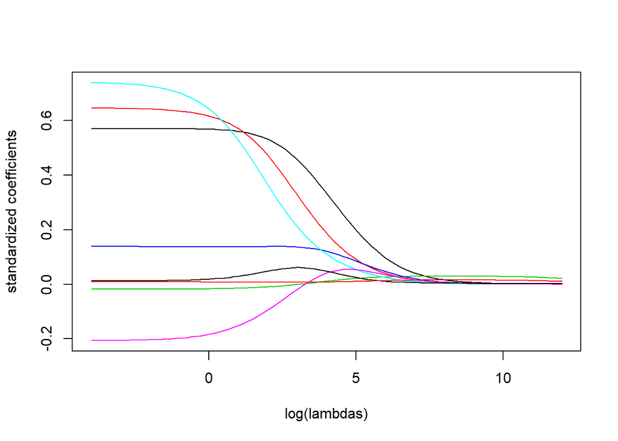

```r
# per piu lambda
lambdas = exp(seq(-4,12,length.out = 100))
hatbetas =sapply(lambdas, function(lambda)
solve(t(x)%*%x + (lambda*diag(p)) )%*%t(x)%*%y
)
matplot(log(lambdas), t(hatbetas), type="l", lty=1, ylab="standardized coefficients") # metto il log cosi da riuscire a vedere meglio come cambia al variare di lambda
```

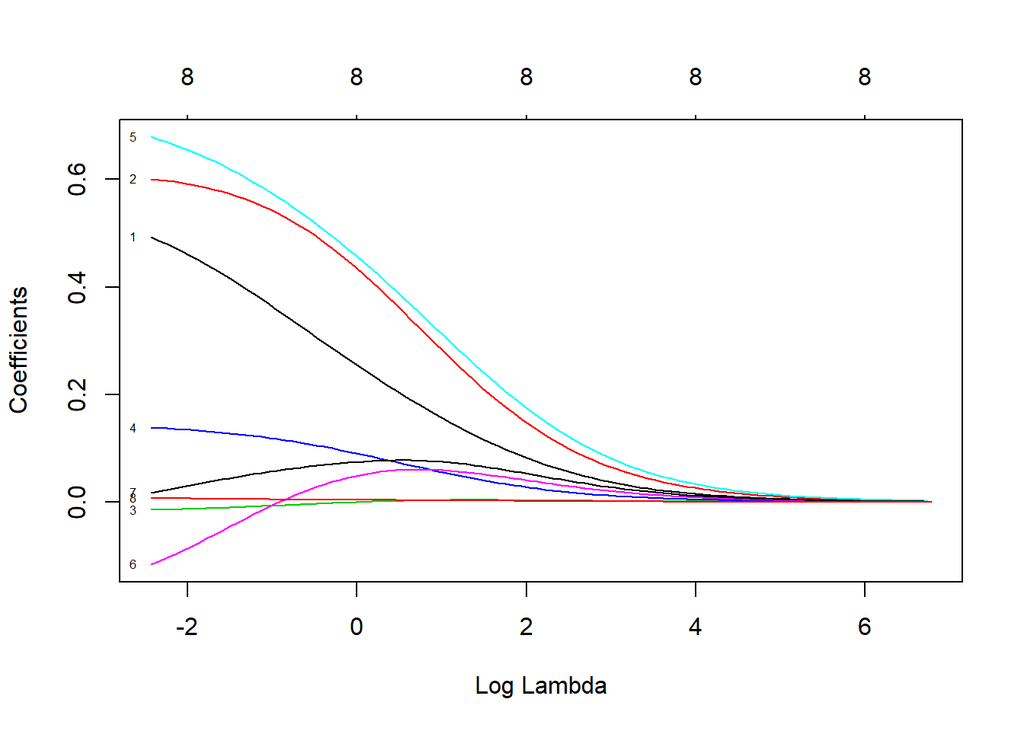

```r
# con pacchetto
library(glmnet)

fit = glmnet(x, y, alpha = 0)
plot(fit ,xvar = "lambda", label = T)
```

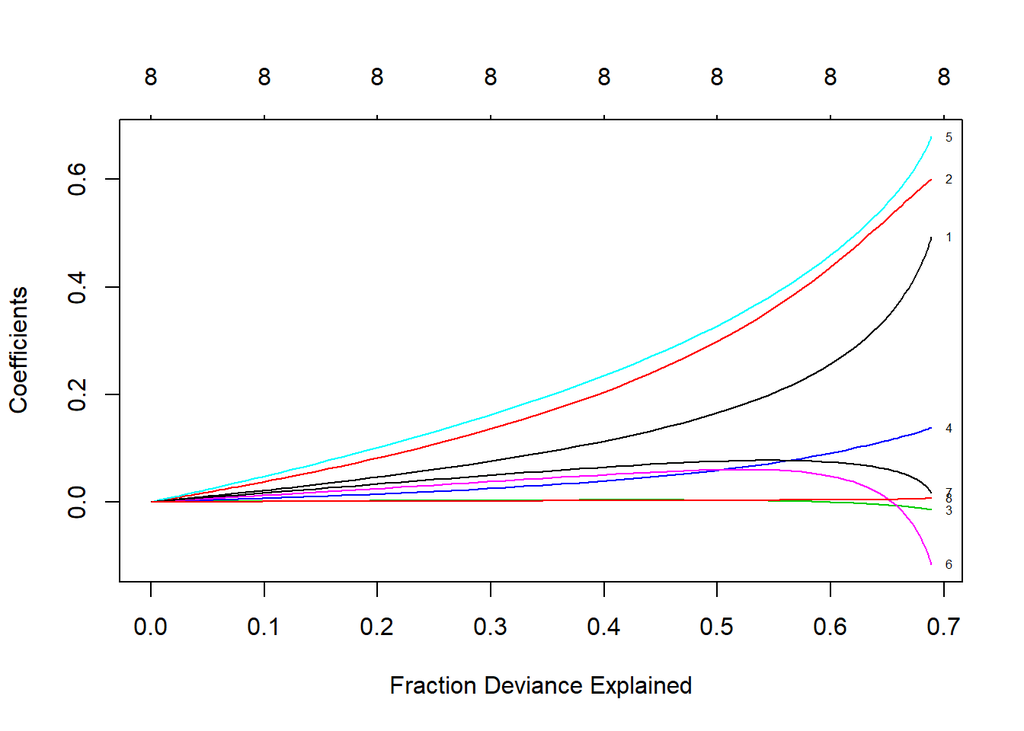

```r
plot(fit ,xvar = "dev", label = T)
```

```r
fit = glmnet(x, y, alpha = 0, family="gaussian", lambda=0.005)
coef(fit)
```

```
9 x 1 sparse Matrix of class "dgCMatrix"
                      s0
(Intercept)  0.398849222
lcavol       0.570438278
lweight      0.613839194
age         -0.018735879
lbph         0.144425338
svi          0.733225331
lcp         -0.199498323
gleason     -0.025118815
pgg45        0.009263465
```

```r
solve(t(x)%*%x + (0.005*diag(p)) )%*%t(x)%*%y
```

```
                [,1]
lcavol   0.570620778
lweight  0.645973184
age     -0.018091800
lbph     0.138328796
svi      0.740801901
lcp     -0.206697195
gleason  0.012008682
pgg45    0.008742537
```

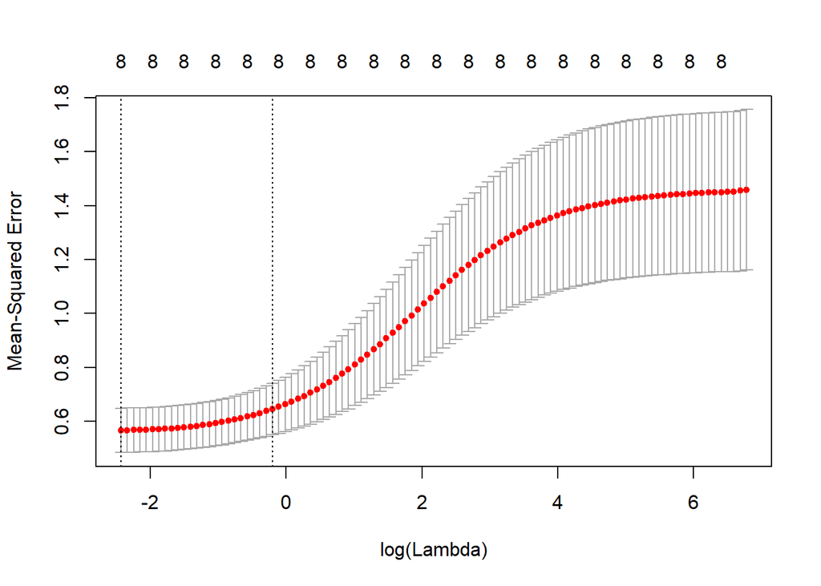

```r
####
cv.ridge<-cv.glmnet(x, y, alpha = 0, family="gaussian")
plot(cv.ridge)
```

```r
lambda_min<-cv.ridge$lambda.min




fit = glmnet(x, y, alpha = 0, family="gaussian", lambda=lambda_min)

M<-t(x.m)%*%x.m +
as.matrix(log(lambda_min)*diag(p+1))
# M0<- as.matrix(log(lambda_min)*diag(p+1))
# M0[1,1]<-0
# M<-t(x.m)%*%x.m +M0
coefficienti_betaridge<-solve(M )%*%t(x.m)%*%y


cbind(coef(fit),coefficienti_betaridge)
```

```
9 x 2 sparse Matrix of class "dgCMatrix"
                      s0
(Intercept)  0.095787016  0.019445236
lcavol       0.492665201  0.556725754
lweight      0.601187986  0.705456082
age         -0.014815392 -0.022102269
lbph         0.137975748  0.151067757
svi          0.679548990  1.234278829
lcp         -0.116701755 -0.302569889
gleason      0.017201107 -0.002277780
pgg45        0.007078254  0.009087962
```

```r
mse_reg<-sqrt(sum((y.star-pre.dict(coefficienti_betaridge,1:m))^2))
# Ridge estimate
#  require(MASS)
#  fit2<-lm.ridge(y~x, lambda=lambda_min, alpha=0)
#  fit2$coef
#  coef(fit2)
#
```

### Ridge regression bias-variance trade-off

- The linear operator
  $$\mathbf{W}^{\lambda} = [\mathbf{I}_{p\times p} + \lambda(\mathbf{x}^\mathsf{T}\mathbf{x})^{-1}]^{-1}$$
  transforms the OLS estimator into the ridge estimator
  $$\mathbf{W}^{\lambda} \hat{\boldsymbol{\beta}} = \hat{\boldsymbol{\beta}}^{\lambda}$$
- Bias
  $$\mathbb{E}(\hat{\boldsymbol{\beta}}^{\lambda}) = \mathbf{x}^\mathsf{T}\mathbf{x}(\lambda\mathbf{I}_{p} + \mathbf{x}^\mathsf{T}\mathbf{x})^{-1} \boldsymbol{\beta}$$
- Variance
  $$\mathbb{V}\mathrm{ar}(\hat{\boldsymbol{\beta}}^{\lambda}) = \sigma^2 \mathbf{W}^{\lambda} (\mathbf{x}^\mathsf{T}\mathbf{x} )^{-1}(\mathbf{W}^{\lambda})^\mathsf{T}$$

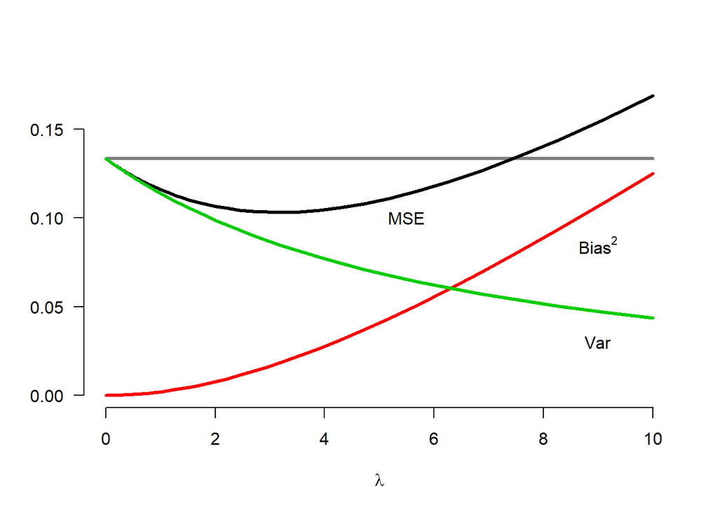

### Choice of the penalty parameter

- Throughout the introduction of ridge regression and the subsequent discussion of its properties the penalty parameter is considered known or given
- In practice, it is unknown and the user needs to make an informed decision on its value
- Usually by cross-validation or generalized cross-validation

```r
# Ridge regression
require(glmnet)
hatlambda<-lambda_min
K = 5
set.seed(123)
ridge.cv<-cv.glmnet(x,y,alpha=0, nfolds = K, grouped=FALSE)
hatlambda <-ridge.cv$lambda.min
yhat.ridge = predict(ridge.cv, s=hatlambda, newx=x.star, exact=TRUE)
err.ridge = mean( (yhat.ridge - test$lpsa)^2 )
err.ridge
```

```
[1] 0.4943793
```

## Lasso

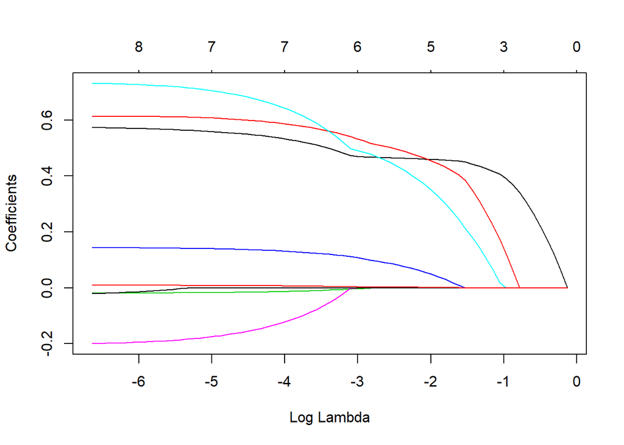

```r
# LASSO
fit.lasso <- glmnet(x, y, alpha=1)
plot(fit.lasso, xvar="lambda")
```